# Juntos Project Initial Report

Baseline Assessment Cleaning and Recommendations

Alejandra Garcia Isaza

March 2021

# Juntos Project Description

## Study and intervention details

The *Juntos* Project was a three-year study led by the University of Oregon’s Center for Equity Promotion [CEQP.](https://ceqp.uoregon.edu/). The project developed a culturally specific family–school partnership intervention, *Conexiones: Families and Schools United for Equity* (hereafter referred to as *Conexiones*), designed to enhance Latino parents’ and educators’ capacities to effectively support Latino student success.

The *Conexiones* curricula was built on Latino cultural assets, addressed common challenges confronting immigrant students and families in terms of school success, and utilized effective strategies for increasing educators’ awareness of Latino cultures and the barriers that exist for Latino immigrant students and families in schools. It also focused on building effective family-school communication and partnerships with the aim of improving Latino students’ academic success.

The six participating schools belonged to three different school districts in the state of Oregon and were randomly assigned to either a control group or a intervention group that received the *Conexiones* intervention program. Study participants completed assessments at three different time points (baseline, immediately post-intervention, and 12-month post-intervention). The complete dataset in the project is made of three waves of data with separate assessments for each participant type (parents, students, and educators).

## Report details

This report will be focusing only on the baseline assessment and is intended to describe the data cleaning process with the aim of helping CEQP staff replicate these procedures in subsequent waves of data and future projects. The report will also include a brief description of the sociodemographic characteristics of the study participants, the scale creation process, the average scores of participants’ responses in regards to major study constructs, and recommendations for more advanced statistical analyses that link the different types of participants in the study.

[figure not shown]

# Data Cleaning procedures

The following section describes the data cleaning procedures I performed in each of the participant’s type datasets. I performed data cleaning using the [R](https://www.r-project.org/) and [R Studio](https://rstudio.com/) softwares, but had in mind that end users of the cleaned datasets will likely be SPSS users.

## Educator’s dataset

The raw dataset had 43 observations and 202 variables of which 17 were metadata variables created by Qualtrics, the software used to develop the assessment surveys. Of the 43 observations, one case, participant with `id` 153 had incomplete data.

In the following code, I removed all but one of the metadata variables, `response_id`, that is an unique identifier assigned by Qualtrics that resulted handy in dealing with duplicated ids. Other data cleaning procedures are described in the comments marked with a # sign.

```r
elt_w1_clean <- w1_raw_elt %>%
  janitor::clean_names() %>% # function that formats variables' names
  select(-1:-8, -10:-17, -202) %>% # selecting out columns with metadata
  rename(c("id" = "pj")) %>% # renaming id variable
  arrange(id) # ordering participants ids in descending order
```

### 0.0.1 Dealing with duplicated ids

When evaluating if the dataset had duplicated ids, I found that `id` 257 was duplicated and there was no `id` 254. In the table below, I am just showing a few variables and participants from `school` 2.

| response_id | id | school | q1 | q2 | q3 |
| --- | --- | --- | --- | --- | --- |
| R_1NsKbbg0xSNm9DI | 251 | 2 | 3 | 3 | 2 |
| R_Xvok02kOfilkkV3 | 252 | 2 | 3 | 3 | 4 |
| R_294kWxIg2imaph1 | 253 | 2 | 4 | 3 | 3 |
| R_3NEywI5hBzdP9Kt | 255 | 2 | 3 | 2 | 3 |
| R_3McjQ3QdB3iSnbT | 256 | 2 | 4 | 3 | 4 |
| R_6EELe7Uuwi9W7zX | 257 | 2 | 2 | 2 | 3 |
| R_3IRUos8weYHpWB1 | 257 | 2 | 4 | 3 | 3 |

After checking with CEQP’s research assistant, I corroborated that one of the duplicated cases of `id` 257 in fact was `id` 254. I fixed this mistake with the code below using the `response_id` variable and the [mutate](https://dplyr.tidyverse.org/reference/mutate.html) and [case_when](https://dplyr.tidyverse.org/reference/case_when.html) functions.

```r
elt_w1_clean <- elt_w1_clean %>%
  mutate(id = case_when(response_id == "R_6EELe7Uuwi9W7zX" ~ "254",
                        TRUE ~ as.character(id))) %>%
  arrange(id)
```

### 0.0.2 Dealing with survey coding errors

The id protocol followed in CEQP projects is very straightforward. They usually use three digits for each individual participant id and use the first of these three digits to indicate the school id. In this system, ids in the 100’s would belong to school 1, ids in the 200’s to school 2, and so on.

By visual inspection I dentified that the first digit of the indvidual ids in the `id` variable did not correspond to the ids in the school id variable `school` for schools 3, 4, 5, and 6. In the table below, I selected four variables and only the first row of data of each of the six schools to ilustrate this point.

| id | school | q1 | q2 | q3 |
| --- | --- | --- | --- | --- |
| 150 | 1 | 4 | 3 | 3 |
| 250 | 2 | 4 | 4 | 3 |
| 350 | 4 | 4 | 3 | 3 |
| 450 | 3 | 3 | 3 | 3 |
| 550 | 6 | 3 | 3 | 3 |
| 650 | 5 | 4 | 3 | 3 |

As can be seen in the table above, ids in the 300’s are coded to belong to `school` 4 and ids in the 400’s are coded to belong to `school` 3. I am calling this flip-flopped school ids. Schools 5 and 6 were also flip-flopped.

At first, I thought that this could be due to an error in the data exporting process and it seemed like an easy enough fix to make. I thought I just needed to recode the names of the levels of the `school` variable. Later I found that this fix did not solve the issue. It took me a couple of months to identify that the error was coded in the Qualtrics survey.

The images below are screenshots of the same raw data SPSS file downloaded directly from Qualtrics. In figure 1, it can be seen that when the *value labels* button is “on” (i.e. showing value labels and not values), it appears as if there was no flip-flop because the names of the schools coincided with the numbers that were assigned to them. Indeed, “Kelly” was school 3 and its participants were identified with ids in the 300’s and “ATA” was school 4 and its participants were identified with ids in the 400’s, and so on.

[figure not shown]

Figure 1: Value labels button on.

This changed when the *value labels* button was “off”. In the image below, the flip-flopped school ids is evident again:

[figure not shown]

Figure 2: Value labels button off

This survey coding error meant that the `school` variable’s value labels properly corresponded to the participants’ ids, but the variable’s values did not. Instead of recoding the values, I decided to create a new variable called `school_id` and delete the flawed original variable `school`.

In the code below, I used the first digit of the individual participant id variable `id` as the reference for the new `school_id` variable, following CEQP’S id protocol. I also created a new variable called `condition` to indicate which schools were randomly assigned to the control group (coded as 1) or to the intervention group (coded as 2).

I coded schools identified with a `school_id` odd number (1, 3, and 5) as the control schools and the schools identified with an even number (2, 4, and 6) as the intervention schools, as directed by CEQP’s research assistant. Finally, I also created a `wave` variable to indicate the wave of the data.

```r
elt_w1_clean_2 <- elt_w1_clean %>%
  mutate(school_id = str_sub(id, 1, 1), # new school id variable
         condition = case_when(
           school_id == "1" | school_id == "3" | school_id == "5" ~ "1",
           school_id == "2" | school_id == "4" | school_id == "6" ~ "2")) %>% # new condition variable
  select(school_id, condition, everything()) %>%
  add_column(wave = 1, .before = 9) %>% # new wave variable
  select(- school) # deleting school variable
```

The `condition` and `school_id` variables I created in the previous code were string variables. In the code below I made them numeric so they can be used in quantitative analyses. I also added value labels with the `set_vall` function so that SPSS users can use the *value labels* button.

In the code below I also fixed a response option coding error I identified in the variable `q68`. Throughout most of the survey, response options were coded as “Strongly Disagree” = 1, “Disagree” = 2, “Agree” = 3, “Strongly Agree” = 4, “No response” = 99; however, in variable `q68` the response option “No response” was coded as 5.

I fixed this using the ifelse function, specifying that if this variable had a response of 5, it should be changed to 99. Finally, I set the variable and value labels with the [set_varl](https://nicedoc.io/martinctc/surveytoolbox) and [set_vall](https://nicedoc.io/martinctc/surveytoolbox) functions, respectively, because sometimes procedures performed with R strips out these labels.

```r
elt_w1_clean_3 <- elt_w1_clean_2 %>%
  mutate(condition = as.numeric(condition),
         condition = set_vall(condition, c("control" = 1, "intervention" = 2)),
         school_id = as.numeric(school_id),
         school_id = set_vall(school_id, c("cascade" = 1, "prairie_mountain" = 2, "kelly" = 3, "ata" = 4, "briggs" = 5, "agnes_stewart" = 6)),
         q68 = ifelse(q68 == 5, 99, q68),
         q68 = set_varl(q68, "When I communicate with Latino families, I keep in mind that many Latino parents may not understand how to navigate the educational system in this
country."),
         q68 = set_vall(q68, c("Strongly Disagree" = 1, "Disagree" = 2, "Agree" = 3, "Strongly Agree" = 4, "No response" = 99)))
```

### 0.0.3 Dealing with split out responses from multiple choice, unique answer variables

In this dataset, several multiple choice variables that were originally meant to have a single answer, were spread out as if they had multiple answers. I believe this was because in the Qualtrics survey development process, the option for *Multiple answer* was selected, instead of *Single answer*.

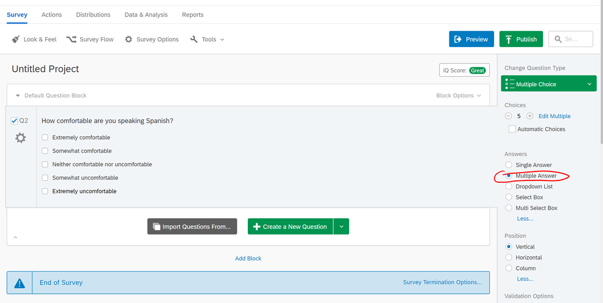

Figure 3: Qualtrics survey development

When this happens, participants could select mutually exclusive options, like this:

[figure not shown]

Figure 4: Qualtrics survey preview

When *Multiple answer* is selected, Qualtrics splits these multi-value fields into columns, assigning a value of 1 if a response option is chosen and a value of 0 if a response option is not chosen. In the following code, I collapsed the Spanish variable that was split out so it could be easily used in analyses. To avoid overwhelming the reader, I am omitting the code I used to collapse other language variables. I used the same procedure in all of these variables.

In the code below, the function [pivot_longer](https://tidyr.tidyverse.org/articles/pivot.html) makes the dataset “long” as it increases the number of rows and decreases the number of columns. This function gathers varables’ names under the new variable `item_2` and gathers the values of these variables under the new variable `spanish_comfort`. Then, I chose only the options that had a value of 1, indicating when a participant chose that response option.

Finally, I recoded the response options to follow this scheme: “Not at all comfortable” = 1, “Somewhat comfortable” = 2, “Comfortable” = 3, “Very comfortable” = 4, “No response” = 99.

```r
# collapsing spanish variables
spa <- elt_w1_clean_3 %>%
  select(id, starts_with("q132_2")) %>% # creating a dataset with only the id and Spanish variables
    pivot_longer(
      cols = starts_with("q132_2"),
      names_to = "item_2",
      values_to = "spanish_comfort",
      values_drop_na = TRUE) %>%
   filter(spanish_comfort == 1) %>%
  mutate(spanish_comfort = case_when(item_2 == "q132_2_1" ~ "1",
                                     item_2 == "q132_2_2" ~ "2",
                                     item_2 == "q132_2_3" ~ "3",
                                     item_2 == "q132_2_4" ~ "4",
                                     item_2 == "q132_2_99" ~ "99",
                        TRUE ~ as.character(spanish_comfort))) %>%
  select(-item_2) # selecting out variable with repetitive information
```

When all the language variables were collapsed I tested if there were duplicated cases and I found that participant identified with `id` 454 chose response option 1 and response option 2.

| id | spanish_comfort |
| --- | --- |
| 451 | 3 |
| 452 | 3 |
| 453 | 2 |
| 454 | 1 |
| 454 | 2 |
| 455 | 2 |
| 456 | 1 |
| 457 | 2 |
| 458 | 2 |

Because I can only assume that this was an entry error because the choices are mutually exclusive, “Not at all comfortable” = 1, vs. “Somewhat comfortable” = 2, I used the distinct function to retain only unique values.

For this case, option 1 = “Not at all comfortable” was retained as the function “assumes” the second option is the duplicative.

```r
spa_2 <- spa %>%
  distinct(id, .keep_all = TRUE)
```

| id | spanish_comfort |
| --- | --- |
| 451 | 3 |
| 452 | 3 |
| 453 | 2 |
| 454 | 1 |
| 455 | 2 |
| 456 | 1 |
| 457 | 2 |
| 458 | 2 |

The last step in this process was making the language variables numeric so they could be used in quantitative analyses and adding the value labels so that the SPSS users can use the *value labels* button. I used the code below to do this.

```r
elt_w1_clean_4 <- elt_w1_clean_4 %>%
  mutate(english_comfort = as.numeric(english_comfort),
         english_comfort = set_vall(english_comfort, c("not at all comfortable" = 1, "somewhat comfortable" = 2, "comfortable" = 3, "very comfortable" = 4, "no response" = 99)),
         spanish_comfort = as.numeric(spanish_comfort),
         spanish_comfort = set_vall(spanish_comfort, c("not at all comfortable" = 1, "somewhat comfortable" = 2, "comfortable" = 3, "very comfortable" = 4, "no response" = 99)),
         other1_lang_comfort = as.numeric(other1_lang_comfort),
         other1_lang_comfort = set_vall(other1_lang_comfort, c("not at all comfortable" = 1, "somewhat comfortable" = 2, "comfortable" = 3, "very comfortable" = 4, "no response" = 99)),
         other2_lang_comfort = as.numeric(other2_lang_comfort),
         other2_lang_comfort = set_vall(other2_lang_comfort, c("not at all comfortable" = 1, "somewhat comfortable" = 2, "comfortable" = 3, "very comfortable" = 4, "no response" = 99)),
         )
```

As shown, the following variables were the result of the collapsing process described above: `english_comfort`, `spanish_comfort`, `other1_lang_comfort`, and `other2_lang_comfort`.

### 0.0.4 Renaming demographic variables

In the code below, I used the rename function to rename the demographic variables that I will use to describe participants’s characteristics in the next section of this report. This function uses a “new name” = “old name” pattern. Very straightforward!

At the end I selected out a few variables that did not have meaningful information. For instance, variable `q127` was a response/no response question that only indicated if participants chose to answer it. The meaningul information was contained in variable `q127_1_text` that was renamed as `age`.

```r
elt_w1_clean_5 <- elt_w1_clean_4 %>%
  rename(c("age" = "q127_1_text"),
         c("birth_country" = "q128"),
         c("another_birth_country_text" = "q128_2_text"),
         c("age_first_moved_us" = "q129_1_text"),
         c("white" = "q130_1"),
         c("hispanic_latino_spanish" = "q130_2"),
         c("black_african_american" = "q130_3"),
         c("asian" = "q130_4"),
         c("american_indian_alaska_native" = "q130_5"),
         c("indigenous_americas" = "q130_6"),
         c("middle_eastern_north_african" = "q130_7"),
         c("native_hawaiian_pacific_islander" = "q130_8"),
         c("race_ethnicity_other" = "q130_9"),
         c("race_ethnicity_no_response" = "q130_99"),
         c("indigenous_americas_text" = "q130_6_text"),
         c("race_ethnicity_other_text" = "q130_9_text"),
         c("gender_id" = "q131"),
         c("years_in_position" = "q133"),
         c("years_in_school" = "q134"),
         c("equity_leadership" = "q135_1"),
         c("cultural_responsiveness" = "q135_2"),
         c("restorative_practices" = "q135_3"),
         c("diversity" = "q135_4"),
         c("ell" = "q135_5"),
         c("cont_ed_other" = "q135_6"),
         c("cont_ed_na" = "q135_88"),
         c("cont_ed_no_response" = "q135_99"),
         c("cont_ed_other_text" = "q135_6_text")) %>%
  mutate(age = as.numeric(age)) %>%
  select(-q127, -q129, -q131_3_text) # selecting out because they did not have meaningful info
```

# Participant descriptives

In the following section, I used descriptive statistics to summarize participants’ characteristics. In this analysis, I treated responses such as “99 = not applicable” or “88 = no response” as missing values. Other category of missing values were responses coded by Qualtrics as “-99 = seen but unanswered”, when participants were not forced to respond.

In the code below I applied a function I created `recode_missing_df` to recode these values as `NA`, the way R codes missing values.

```r
elt_w1_clean_6 <- recode_missing_df(elt_w1_clean_5)
```

## Educator’s characteristics

Educators in this first wave of data (*n* = 43) had a mean age of 42.89 years, with an age range between 24 and 62 years. The Overwhelming majority of educators were identified as female (72.09%). A little less than half of the educators were teachers (48.84%), followed by administrators (16.27%) and other classified staff (16.27%). The remaining 20% of the sample was comprised of educational assistants, counselors, and other certified staff. About half of the educators have been in their current career position, regardless of school site, for over 10 years. About 12% of the educators have been in their current career position for less than a year.

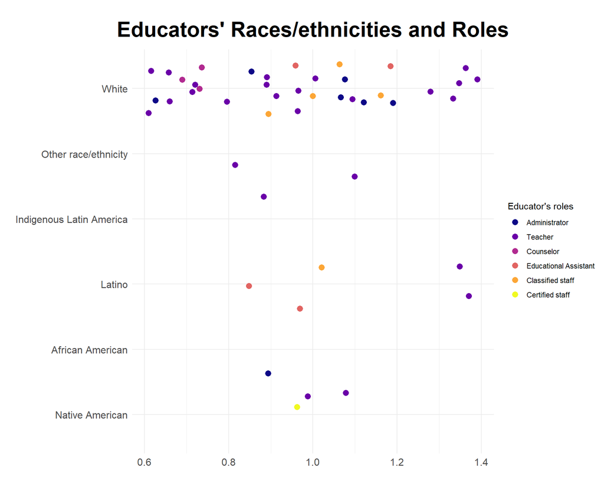

```r
tidy_d <- elt_w1_clean_6 %>%
  select(4, 5, 136, 139:147, 151, 152, 163, 164) %>%
  gather(race, count, 4:12) %>%
  filter(count == 1)

viz <- tidy_d %>%
  mutate(race = as.factor(race),
         race = fct_recode(race,
                           "White" = "white",
                            "Other race/ethnicity" = "race_ethnicity_other",
                            "Indigenous Latin America" = "indigenous_americas",
                            "Latino" = "hispanic_latino_spanish",
                            "African American" = "black_african_american",
                            "Native American" = "american_indian_alaska_native"),
         years_in_position = as.factor(years_in_position),
         participant_role = as.factor(participant_role),
         participant_role = fct_recode(participant_role,
                           "Administrator" = "1",
                            "Teacher" = "2",
                            "Counselor" = "3",
                            "Educational Assistant" = "4",
                            "Classified staff" = "5",
                            "Certified staff" = "6"))


ggplot(viz, aes(fct_reorder(race, count), count)) +
  geom_point(aes(color = participant_role), position = "jitter", size = 3) +
  coord_flip() +
  scale_colour_viridis_d("Educator's roles", option = "plasma") +
  theme_minimal() +
  labs(title = "Educators' Races/ethnicities and Roles",
       y = "",
       x = "") +
  theme(plot.title = element_text(family = "sans", size = 25, face = "bold", hjust = 0.5, margin = margin(20, 20, 10, 10)),
        axis.text = element_text(family = "sans", size = 12))
```

```r
# why is the count in decimals? How to take it out?
# better way to organize the races?
```